# Exploring biotic signals in vegetation assembly from the LGM to the Anthropocene

## BIODYNAMICS PROJECT

talking to <ORACLE>:

Exploring biotic signals in vegetation assembly from the LGM to the Anthropocene

Ondrej Mottl

BES Annual Meeting 2026 || 14–17 December 2026 || Online

NARRATIVE INTERFACE: **ORACLE**

…/…/…

ANALYTICAL OUTPUTS: **REAL**

## … booting

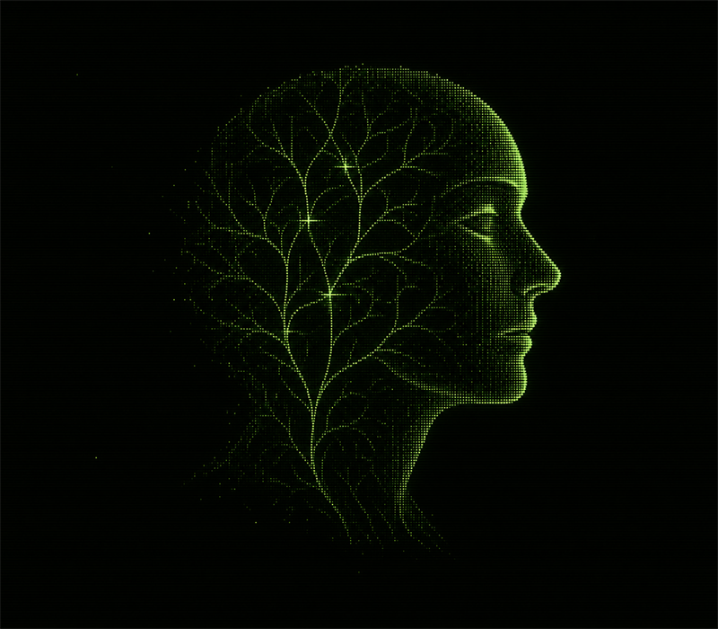

System online

Greetings Dr. Mottl

I am Observational Runtime for Analysis of Community-Level Ecology

<ORACLE> for short

I am here to assist you in analyzing vegetation patterns on Earth

Awaiting ecological query.

Proceed? [Y]/[N]?

Is there a scale dependence in the amount of unexplained variation (potentially due to biotic interactions) structuring vegetation since the Last Glacial Maximum?

## Is there a scale dependence in the amount of unexplained variation (potentially due to biotic interactions) structuring vegetation since LGM?

Query accepted

Plan to partition observed plant co-occurrence into:

spatial structure

climate response

species-species association (residual)

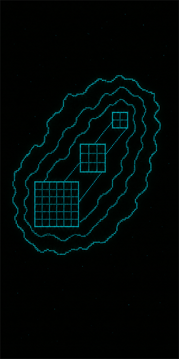

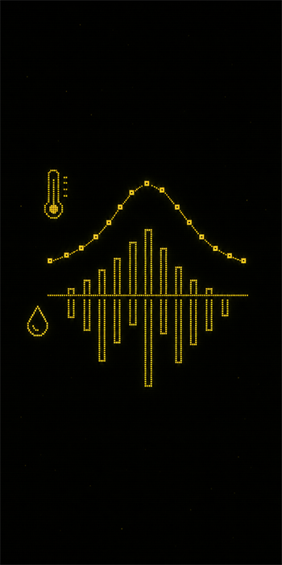

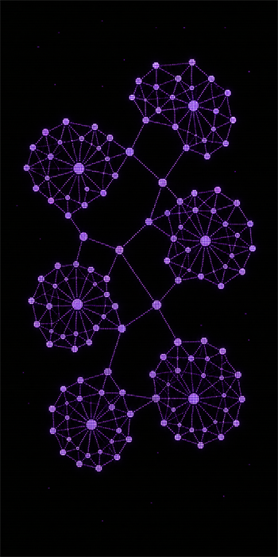

## DATA: <VegVault>

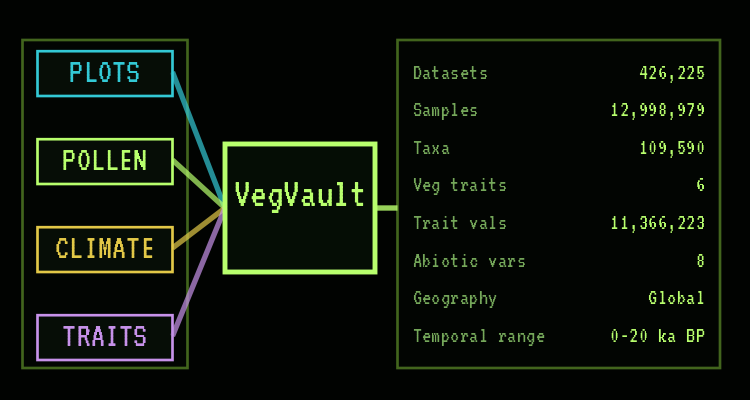

USED SAMPLE COVERAGE

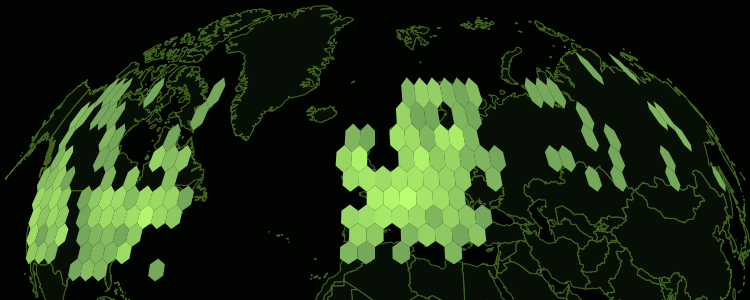

<VegVault> database: publicly available, open-source database

Community records, climate predictors, site coordinates, and functional traits are loaded as separate streams

Due to data availability, I will focus on the Northern Hemisphere of the planet since the LGM

[figure not shown]

[figure not shown]

## Preparing community and climate streams

Data extracted, now preparing …

Community stream normalised

- proportions filtered
- Taxa are classified automatically against GBIF and filtered
- Age uncertainty propagated to estimate counts

Climate stream screened

- Redundant predictors are removed before model fitting

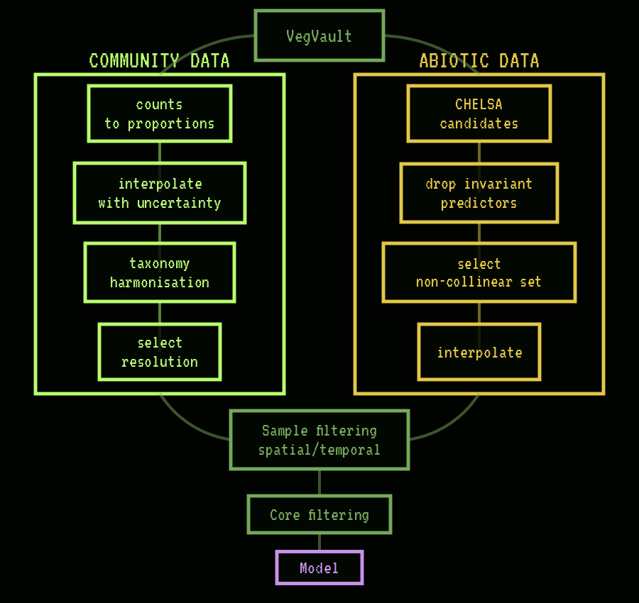

## Model core: environment, space, association

$Y_{ij} \sim \operatorname{Bernoulli}\!\left\{\Phi\!\left(\eta_{ij}\right)\right\}$

$\eta_{ij} = \alpha_j \;+\;$

$\sum_{k=1}^{K}\,\beta_{jk}\,x_{ik} \;+\; \sum_{k=1}^{K}\,\gamma_{jk}\,x_{ik}\,a_i$ $\;+\;$

$\sum_{m=1}^{M}\,\delta_{jm}\,\operatorname{MEM}_{im}$ $\;+\;$

$u_{ij}$

$\mathbf{u}_i = (u_{i1}, \ldots, u_{iJ}) \sim \mathcal{N}(\mathbf{0}, \Sigma)$

Model assembled.

{sjSDM} as the modeling framework

Abiotic predictors explain shared response

Moran Eigenvector Maps (MEMs) absorb spatio-temporal autocorrelation

Residual covariance carries species-species association signal

Env: `~ (x1 + ... + xK) * age - age`

Space: `~ 0 + (MEM1 + ... + MEMM)`

Association: off-diagonal `Sigma` from `sjSDM::bioticStruct()`

## Variance decomposition

Decomposition ready

Focus: residual association component

Report what remains after climate and spatial structure have made their claims

Caution: co-occurrence is not proof of interaction.

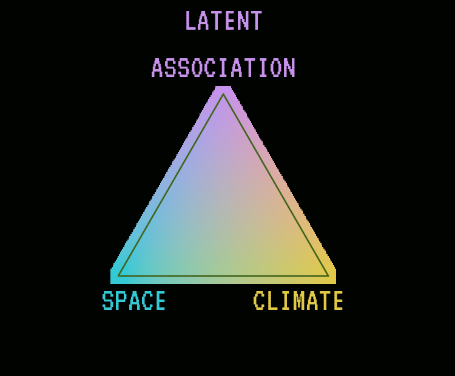

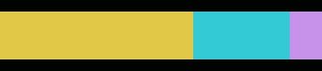

[figure not shown]

## Three analysis axes

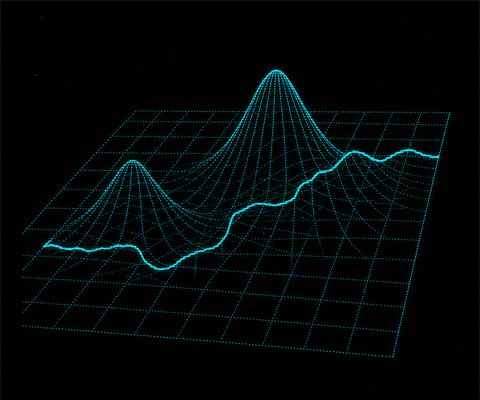

Spatial

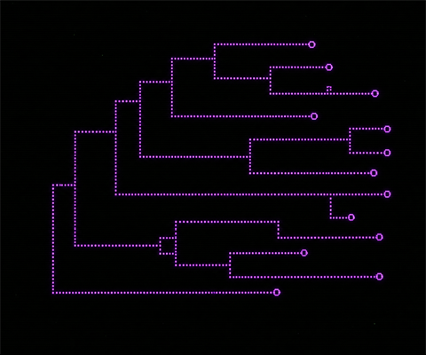

Taxonomic

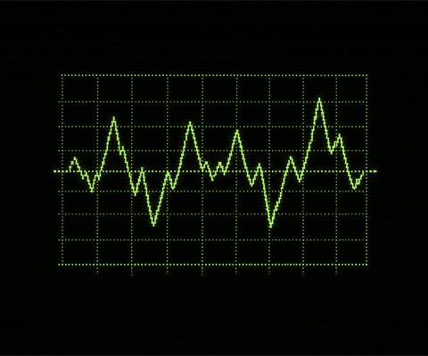

Temporal

Three routes selected:

Spatial-resolution runs : change with spatial scale

Taxonomic aggregation levels : change through classification

Temporal slice tests : change through time

```
▄█████ ▄▄▄▄   ▄▄▄ ▄▄▄▄▄▄ ▄▄  ▄▄▄  ▄▄       ▄▄▄▄  ▄▄▄▄  ▄▄▄  ▄▄    ▄▄▄▄▄
▀▀▀▄▄▄ ██▄█▀ ██▀██  ██   ██ ██▀██ ██      ███▄▄ ██▀▀▀ ██▀██ ██    ██▄▄
█████▀ ██    ██▀██  ██   ██ ██▀██ ██▄▄▄   ▄▄██▀ ▀████ ██▀██ ██▄▄▄ ██▄▄▄
```

## Spatial results: local to continental

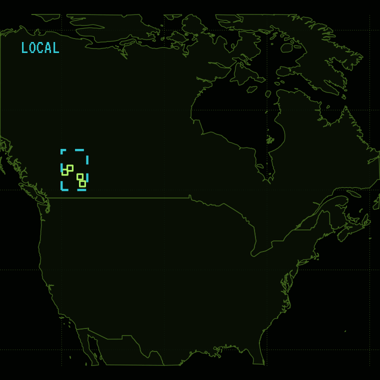

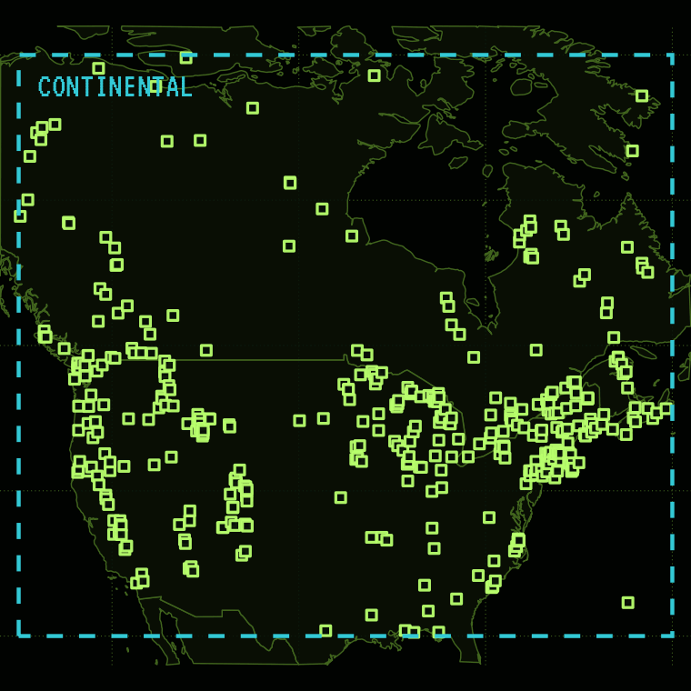

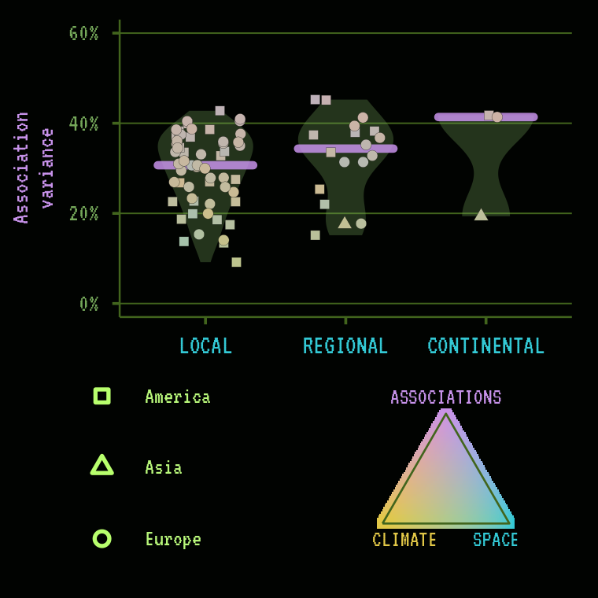

Results are preliminary

```
██████ ▄▄▄  ▄▄ ▄▄  ▄▄▄  ▄▄  ▄▄  ▄▄▄  ▄▄   ▄▄ ▄▄  ▄▄▄▄
  ██  ██▀██ ▀█▄█▀ ██▀██ ███▄██ ██▀██ ██▀▄▀██ ██ ██▀▀▀
  ██  ██▀██ ██ ██ ▀███▀ ██ ▀██ ▀███▀ ██   ██ ██ ▀████

           ▄█████  ▄▄▄▄  ▄▄▄  ▄▄    ▄▄▄▄▄
           ▀▀▀▄▄▄ ██▀▀▀ ██▀██ ██    ██▄▄
           █████▀ ▀████ ██▀██ ██▄▄▄ ██▄▄▄
```

## How does the spatial pattern change when we add taxonomic resolution?

Query accepted…

Adding taxonomic axis

Plotting the results

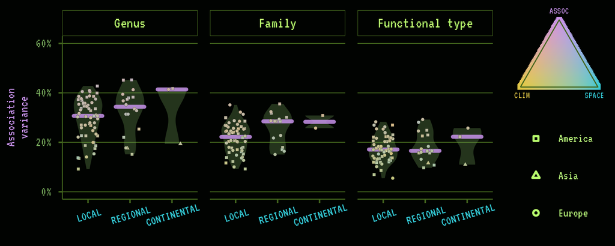

```
██████ ▄▄▄▄▄ ▄▄   ▄▄ ▄▄▄▄   ▄▄▄  ▄▄▄▄   ▄▄▄  ▄▄
  ██   ██▄▄  ██▀▄▀██ ██▄█▀ ██▀██ ██▄█▄ ██▀██ ██
  ██   ██▄▄▄ ██   ██ ██    ▀███▀ ██ ██ ██▀██ ██▄▄▄

         ▄█████  ▄▄▄▄  ▄▄▄  ▄▄    ▄▄▄▄▄
         ▀▀▀▄▄▄ ██▀▀▀ ██▀██ ██    ██▄▄
         █████▀ ▀████ ██▀██ ██▄▄▄ ██▄▄▄
```

## Is the association signal stable through time?

Query accepted

Temporal mode selected: Slicing the data into 500-year windows

Network diagnostics loaded. Co-occurrence structure can change even when variance components look similar

Each slice receives an independent analysis and diagnostic workflow

Plotting the data distribution

Proceed? [Y]/[N]?

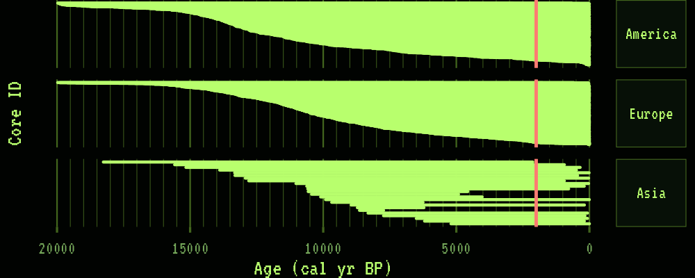

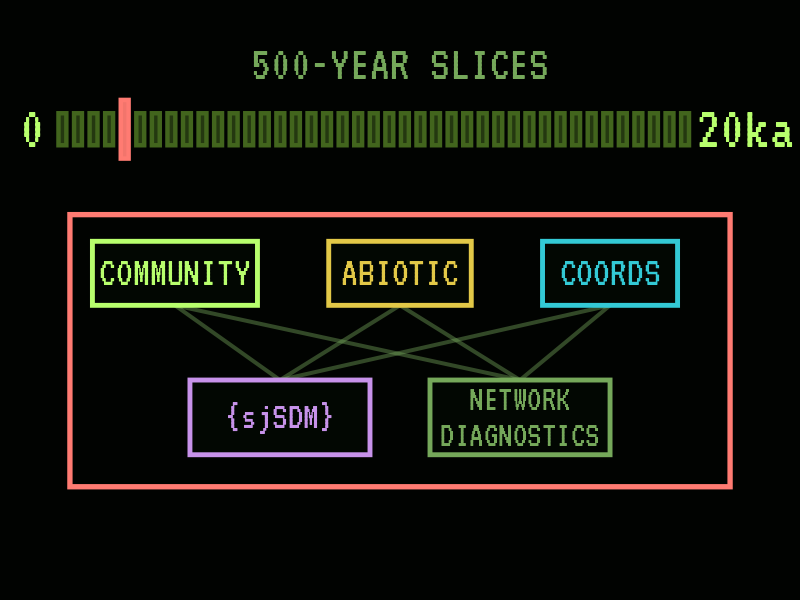

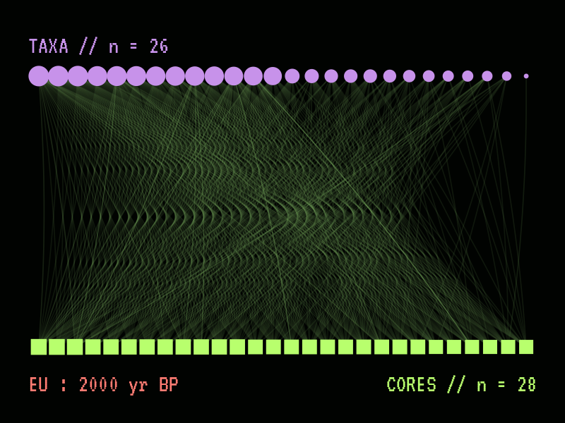

## Temporal trajectories

Plotting temporal trajectories for each continent

[figure not shown]

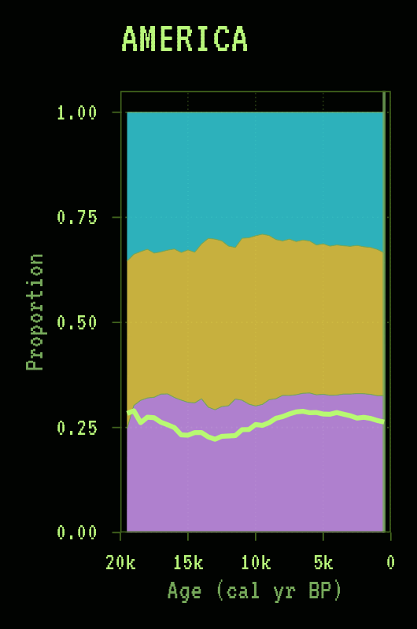

[figure not shown]

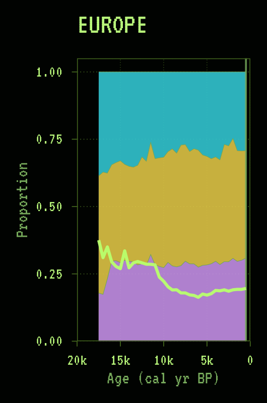

[figure not shown]

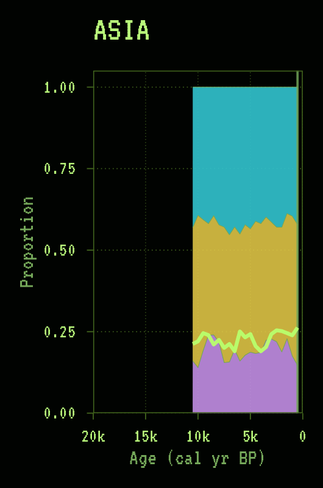

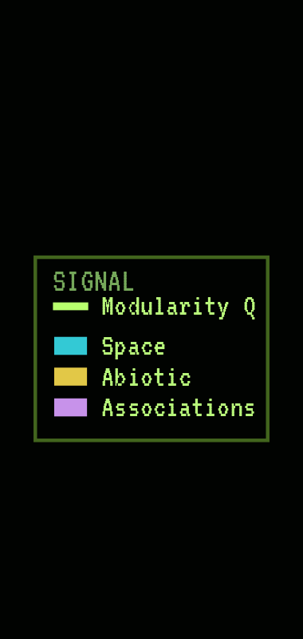

```
▄▄   ▄▄  ▄▄▄  ▄▄▄▄▄▄ ▄▄▄▄  ▄▄ ▄▄ ▄▄   ▄█████  ▄▄▄▄  ▄▄▄  ▄▄    ▄▄▄▄▄
██▀▄▀██ ██▀██   ██   ██▄█▄ ██ ▀█▄█▀   ▀▀▀▄▄▄ ██▀▀▀ ██▀██ ██    ██▄▄
██   ██ ██▀██   ██   ██ ██ ██ ██ ██   █████▀ ▀████ ██▀██ ██▄▄▄ ██▄▄▄
```